# Just some notes about entropy

Kyle Lo

June 23, 2016

# [Information](https://en.wikipedia.org/wiki/Self-information)

Let $X$ be a *discrete* random variable that takes on values according to its probability distribution function $P$.

The amount of **information** gained by observing $X = x$ is defined:

$I(x) = \log \dfrac{1}{P(X = x)} = -\log P(X = x)$

#### Example: Coin

Let $X$ represent the outcome of a coin toss:

- For a fair coin, $P(X = Heads) = 0.5$. Then observing Heads provides $I(Heads) = \log_2 2 = 1$ bit of information.
- For an unfair coin for which $P(X = Heads) = 1$, observing Heads provides $I(Heads) = \log_2 1 = 0$ bits of information.

#### Example: Die

Let $X$ represent the outcome of a die roll:

- For a fair die, $P(X = 1) = 1/6$. Then observing $X = 1$ provides $I(1) = \log_2 6 = 2.58$ bits of information.

## Properties

1. Information is always **non-negative**: $I(x) \geq 0$
2. **Deterministic** events contain no information: $I(1) = 0$
3. Information of independent events is **additive**: $I(x_1, x_2) = I(x_1) + I(x_2) \iff P(X_1 = x_1, X_2 = x_2) = P(X_1 = x_1) P(X_2 = x_2)$

## Interpretation

In the 1940s, Shannon wanted a concept that could quantify the **amount of information** contained in a message sent by a source via electronic communication.

Now, imagine the source is a random variable $X$, and the message is its realized value. Information quantifies the amount of **unpredictability** or **surprisal** of the value of $X$.

It makes sense that **deterministic events contain no information** because there is no uncertainty surrounding their outcomes.

Uncertainty is high when $X$ can take on more values with equal probability; hence, why the outcome of a die roll contains more information than the outcome of a coin toss.

# Entropy

**Entropy** is the average amount of information $E[I(X)]$ in a random variable:

- For discrete $X$: $H(X) = -E[\log P(X=X)] = - \displaystyle\sum_x P(X = x) \log P(X = x)$
- For continuous $X$: $H(X) = -E[\log f(X)] = - \displaystyle\int_x f(x) \log f(x) dx$

#### Example: Binary Entropy

Let $X$ represent a Bernoulli$(p)$ random variable, where $p$ denotes probability of success. Then by definition:

$H(X) = - p \log p - (1 - p) \log (1 - p)$

- If $p = 1$, then $H(X) = 0$. This makes sense since the outcomes of a deterministic event would contain no information on average (recalling that variance is 0 when $p = 1$).
- $H(X)$ is maximized at $p = 0.5$, as seen from the plot below. Intuitively, there is most uncertainty in a coin that’s perfectly fair compared to an unfair coin that favors one side (recalling that variance is maximized when $p = 0.5$). What’s the relationship between Entropy and Variance?

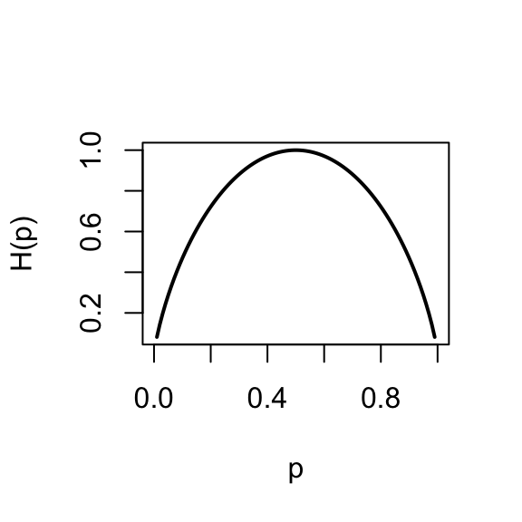

#### Example: Estimating Binary Entropy

Now suppose $p$ is **unknown**, but we attempt to estimate it from a sample $X_1,\dots,X_n$ drawn independently from the Bernoulli$(p)$.

Since $p$ is unknown, we’re missing two necessary components of $H(X)$:

1. $p$ is needed as a weighting component when taking the expectation’s sum
2. $p$ is needed to compute the $\log$ of the pmf evaluated at $X = x$

To address these, we make the following **substitutions**:

1. Use the **sample mean** to approximate taking an expectation
2. Replace $p$ with a estimate based on the sample, such as the maximum likelihood estimate $\widehat{p} = \dfrac{n_{i:x=1}}{n}$

Hence, we have our **estimator**: $\begin{align} \widehat{H}(X) &= -\dfrac{1}{n} \sum_{i=1}^n \log \widehat{P}(X = X_i) \\ &= -\dfrac{1}{n} \sum_{i=1}^n \begin{cases} \log \widehat{p} & \text{if } X_i = 1 \\ \log \left(1- \widehat{p}\right) & \text{if } X_i = 0 \end{cases} \\ &= -\dfrac{1}{n} \left( n_{i:x=1} \log \widehat{p} + n_{i:x=0} \log (1-\widehat{p}) \right) \\ &= -\widehat{p} \log \widehat{p} + (1-\widehat{p}) \log (1-\widehat{p}) \end{align}$

Note that this is equivalent to simply using the derived form of $H(X)$ for a Bernoulli random variable and plugging in $\widehat{p}$ for $p$.

# [Joint Entropy](https://en.wikipedia.org/wiki/Joint_entropy)

In the bivariate setting, the **Joint Entropy** is the average amount of information $E[I(X,Y)]$ in a **pair** of random variables.

- For discrete $X,Y$:  
  $H(X,Y) = -E[\log P(X=X,Y=Y)] = - \displaystyle\sum_x P(X = x, Y = y) \log P(X = x, Y = y)$
- For continuous $X,Y$: $H(X,Y) = -E[\log f(X,Y)] = - \displaystyle\int_x f(x,y) \log f(x,y) dx$

This extends further into the **multivariate** setting.

## Properties

- **Triangle Inequality**: $H(X,Y) \leq H(X) + H(Y)$
  - Equality holds when $X$ and $Y$ are independent
    - $H(X,Y) = -E[\log f(x,y)] = -E[\log f(x) f(y)] = -E[\log f(x)] - E[\log f(y)] = H(X) + H(Y)$

# [Conditional Entropy](https://en.wikipedia.org/wiki/Conditional_entropy)

In the bivariate setting, the **Conditional Entropy** is the average amount of information in a random variable **given** that the value of another random variable is **known**.

$H(Y|X) = E_x\left[H(Y|X=X)\right]$

- For discrete $X,Y$:  
  $H(Y|X) = - \displaystyle \underbrace{\sum_x P(X = x) \underbrace{\displaystyle\sum_y P(Y = y|X = x) \log P(Y = y|X = x)}_{-H(Y|X=x)}}_{\text{Expectation over values of } X} = - \sum_x \sum_y P(X = x, Y = y) \log \dfrac{P(X = x, Y = y)}{P(X = x)}$
- For continuous $X,Y$: $H(Y|X) = - \displaystyle \underbrace{\int_x f(x) \underbrace{\displaystyle\int_y f(y|x) \log f(y|x) dy}_{-H(Y|X=x)} dx}_{\text{Expectation over values of } X} = - \int_x \int_y f(x,y) \log \dfrac{f(x,y)}{f(x)} dy dx$

What’s the difference between $H(Y|X)$ vs $H(Y|X=x)$?

- It’s simple. The former quantifies uncertainty surrounding $Y$ if $X$ is known. The latter is similar, but under a specific $X = x$ value.

## Properties

- $H(Y|X) = 0 \iff Y$ is **completely determined** by $X$
  - In short, $Y$ becomes deterministic when $X$ is known, so $H(Y|X=x) = 0$
- $H(Y|X) \leq H(Y)$
  - Equality holds when $Y$ and $X$ are independent
    - $H(Y|X) = - \displaystyle \int_x f(x) \displaystyle\int_y f(y|x) \log f(y|x) dy dx = - \int_x f(x) \displaystyle \int_y f(y) \log f(y) dy dx = H(Y) \int_x f(x) dx = H(Y)$
  - In short, observing $X$ explains away some of the uncertainty surrounding $Y$
- **Chain rule**: $H(Y|X) = H(X,Y) - H(X)$

  $\begin{align} H(Y|X) &= - \int_x \int_y f(x,y) \log \dfrac{f(x,y)}{f(x)} dy dx \\ &= - \int_x \int_y f(x,y) \log f(x,y) dy dx + \int_x \int_y f(x,y) \log f(x) dy dx \\ &= H(X,Y) + \int_x \log f(x) \int_y f(x,y) dy dx \\ &= H(X,Y) + \int_x f(x) \log f(x) dx \\ &= H(X,Y) - H(X) \end{align}$
  - Suppose we need $H(X,Y)$ bits of information to describe the state of a system determined by random variables $X$ and $Y$. Observing $X$ provides $H(X)$ bits of information. Hence, we need $H(Y|X) = H(X,Y) - H(X)$ more bits of information once $X$ is known.
- **Bayes rule**: $H(Y|X) = H(X|Y) - H(X) + H(Y)$
  - Solve (1) $H(Y|X) = H(X,Y) + H(X)$ and (2) $H(X|Y) = H(X,Y) + H(Y)$

# [Kullback-Leibler Divergence](https://en.wikipedia.org/wiki/Kullback%E2%80%93Leibler_divergence)

Let $p$ and $q$ be two probability distributions. The **KL-divergence** of $q$ from $p$ is a measure of the average amount of information lost when $q$ is used to approximate $p$ (or the information gained when using $p$ instead of $q$):

- For discrete $X$:  
  $KL(P||Q) = E_P\left[\log \dfrac{P(X=X)}{Q(X=X)}\right] = \displaystyle\sum_x P(X = x) \log \dfrac{P(X = x)}{Q(X = x)} = \underbrace{\displaystyle\sum_x P(X = x) \log P(X = x)}_{\approx \text{ } -\text{Entropy of } X} - \underbrace{\displaystyle\sum_x P(X = x) \log Q(X = x)}_{\approx \text{ } -\text{Cross Entropy of } X}$
- For continuous $X$: $KL(p||q) = E_p\left[\log \dfrac{p(X)}{q(X)}\right] = \displaystyle\int_x p(x) \log \dfrac{p(x)}{q(x)} dx = \underbrace{\displaystyle\int_x p(x) \log p(x) dx}_{\approx \text{ } -\text{Entropy of } X} - \underbrace{\displaystyle\int_x p(x) \log q(x) dx}_{\approx \text{ } -\text{Cross Entropy of } X}$

## Interpretation

Statistically, we can think of $KL(p||q)$ as the average amount of information lost when we use an estimated statistical model $q$ as an **approximation** to the true, **unknown** density $p$.

From a Bayesian perspective, we can think $KL(p||q)$ as the average amount of information gained when we update our **prior** distribution $q$ to the **posterior** distribution $p$.

# [Cross Entropy](https://en.wikipedia.org/wiki/Cross_entropy)

Honestly, it’s a little hard to figure out the intuitive meaning of **Cross Entropy** between distributions $p$ and $q$, but it’s an important component that comes out of the KL Divergence equation:

- For discrete $X$:  
  $H(P,Q) = -E_P[ \log Q(X=X) ] = - \displaystyle\sum_x P(X = x) \log Q(X = x)$
- For continuous $X$: $H(p,q) = -E_p[ \log q(X) ] = - \displaystyle\int_x p(x) \log q(x) dx$

#### KL Divergence vs Cross Entropy

In problems for which our goal is to devise a good **approximation** $q$ for an **unknown** density $p$, one would ideally like to solve the **optimization** problem to find a $q$ that **minimizes** $KL(p||q)$.

Unfortunately, $KL(p||q)$ can’t be used because it requires knowledge of the unknown $p$. Luckily, $KL(p||q)$ and $H(p,q)$ are essentially **equal** up to the additive **constant** $H(X)$, since $p$ is non-random.

Furthermore, $H(p,q)$ can be estimated from an independently drawn sample $X_1,\dots,X_n$ from $p$:

$\widehat{H}(p,q) = -\widehat{E}_p[\log q(X)] = -\dfrac{1}{n} \sum_{i=1}^n \log q(X_i)$

This is why we minimize Cross Entropy loss instead of KL Divergence.

#### Example: Estimating Binary Cross Entropy

Again, let $X$ represent a Bernoulli$(p)$ random variable, where $p$ denotes probability of success. Now suppose we constructed $Q(X = x)$ from a sample $X_1,\dots,X_n$ as our approximation of $P(X = x)$.

By definition, we can derive the following form:

$H(P,Q) = p \log q + (1 - p) \log (1 - q)$

where $q = Q(X = 1)$.

And using the estimator provided above: $\begin{align} \widehat{H}(P,Q) &= -\dfrac{1}{n} \sum_{i=1}^n \log Q(X = X_i) \\ &= -\dfrac{1}{n} \sum_{i=1}^n \begin{cases} \log q & \text{if } X_i = 1 \\ \log \left(1- q\right) & \text{if } X_i = 0 \end{cases} \\ &= -\dfrac{1}{n} \left( n_{i:x=1} \log q + n_{i:x=0} \log (1-q) \right) \\ &= - \widehat{p} \log q - (1- \widehat{p}) \log (1-q) \end{align}$

Notice:.

- If we also set $q = \widehat{p}$, then $\widehat{H}(P,Q) = \widehat{H}(X)$.
- But if we use a different estimator for $Q$, then $\widehat{H}(P,Q)$ no longer has form matching the derived form of $H(P,Q)$:
  - Consider something ridiculous like $Q(X = x) = x$ which results in an undefined $\widehat{H}(P,Q)$
  - Or something naive like $Q(X = x) = 0.5$ which results in $\widehat{H}(P,Q) = 1$ for any value of $p$.

This hopefully demonstrates that choice of $Q$ not only impacts the true value of $H(P,Q)$ but also your ability to accurately estimate it.

## Cross Entropy and Logistic Regression

In **Logistic Regression**, the goal is to derive a **conditional mean** model for the binary response $Y$:

$E[Y|X = x] = P(Y = 1|X=x) = p(x) \approx q(x)$

So we want to find some $q$ that approximates $p$ given a particular $X = x$. We also choose to restrict the search space of $q$ by specifying a **functional form**:

$q(x) := \phi(w^Tx)$

$\phi(z) = \dfrac{1}{1 + \exp(-z)}$

One way to select good weights $w$ for $q$ can be to **minimize the cross entropy** between $P$ and $Q$, which are the Bernoulli pmfs of $Y|X=x$ parameterized by $p$ and $q$, respectively.

$\begin{align} \operatorname*{arg\,min}_w H(P,Q) &= \operatorname*{arg\,max}_w E_p[\log q(X) ] \\ &= \operatorname*{arg\,max}_w \left\{ p(X) \log q(X) + (1 - p(X)) \log (1 - q(X)) \right\} \end{align}$

Since we can’t take the expectation without knowledge of $p$, we use a sample $(X_1,Y_1),\dots,(X_n,Y_n)$ to construct an estimate:

$\begin{align} \widehat{H}(P,Q) &= -\dfrac{1}{n} \sum_{i=1}^n \log Q(Y_i = Y_i | X_i = X_i) \\ &= -\dfrac{1}{n} \sum_{i=1}^n \begin{cases} \log q(X_i) & \text{if } Y_i = 1 \\ \log \left(1 - q(X_i) \right) & \text{if } Y_i = 0 \end{cases} \\ \end{align}$

Notice that this doesn’t simplify as cleanly as we saw in the univariate case since each **$q$ now depends on $X_i$**, but this is often equivalently represented:

$\widehat{H}(P,Q) = -\dfrac{1}{n} \sum_{i=1}^n \left( Y_i \log \widehat{Y}_i + (1 - Y_i) \log \left(1 - \widehat{Y}_i\right) \right)$

where $\widehat{Y}_i = q(X_i) = \phi(w^T X_i)$ is our predicted response value given $X_i$.

Hence, we select weights by solving the following **optimization problem**:

$\begin{align} \operatorname*{arg\,min}_w \widehat{H}(P,Q) &= \operatorname*{arg\,max}_w \left\{ \dfrac{1}{n} \displaystyle \sum_{i=1}^n \left( y_i \log \phi(w^Tx_i) + (1 - y_i) \log (1 - \phi(w^Tx_i)) \right) \right\}\\ &= \operatorname*{arg\,max}_w \left\{ \displaystyle \sum_{i : y_i=1} \log \phi(w^Tx_i) + \sum_{i : y_i=0} \log \left(1 - \phi(w^Tx_i) \right) \right\}\\ \end{align}$

# Appendix

Here are some additional notes on related concepts:

## [Pointwise Mutual Information](https://en.wikipedia.org/wiki/Pointwise_mutual_information)

Let $X$ and $Y$ be discrete random varibles that take on values according to their distributions $P_X$ and $P_Y$.

**PMI** is a measure of association between $X$ and $Y$ for a realized value $(x,y)$:

$PMI(x,y) = \log \dfrac{f(x,y)}{f(x)f(y)} = \log \dfrac{f(y|x)}{f(y)} = \log \dfrac{f(x|y)}{f(x)}$

The ratio looks somewhat like a log-likelihood **ratio** between the general probability model and the probability model under **independence** between $X$ and $Y$.

## [Mutual Information](https://en.wikipedia.org/wiki/Mutual_information)

**MI** between two random variables $X$ and $Y$ is a measure of the average amount of information obtained about one variable through the other variable (i.e. how much knowing one variable will reduce uncertainty about the other):

$MI(X,Y) = E[PMI(X,Y)]$

- For discrete $X,Y$:

$\displaystyle\sum_x \sum_y P(X = x, Y = y) \log \dfrac{P(X = x, Y = y)}{P(X = x)P(Y = y)}$

- For continuous $X,Y$: $\displaystyle\int_x \int_y f(x,y) \log \dfrac{f(x,y)}{f(x)f(y)} dy dx$

### Properties

- If $X$ and $Y$ are independent, then $MI(X,Y) = 0$.
  - Intuitively, if $X$ and $Y$ are independent, then observing one provides no information about the other
- If $X$ and $Y$ are deterministic functions of one another, then $M(X,Y) = H(X) = H(Y)$.
  - Intuitively, if $X$ and $Y$ are perfectly related, then observing one eliminates exactly all of the uncertainty surrounding the other, on its own.
- $MI(X,Y) = H(X) - H(X|Y) = H(Y) - H(Y|X)$
  - This is very similar to the Chain Rule for Conditional Entropy, except for the conditioned variable
  - Intuitively, $MI(X,Y)$ is the reduction in uncertainty surrounding one variable when we first make use of observing another variable.
- $MI(X,Y) = H(X) + H(Y) - H(X,Y)$
  - To prove this, factor out the three terms in the logarithm
- $H(X,Y) = H(X|Y) + H(Y|X) + MI(X,Y)$
  - To prove this, use Bayes rule for Conditional Entropy and substitute $MI(X,Y) + H(X,Y)$ for $H(X) + H(Y)$

#### Relationship to KL Divergence

Mutual information is the KL Divergence of the joint density **under independence** from the general joint density.

#### Relationship to Pearson Correlation

Mutual information quantifies all information about dependence, so is not restricted to just linear dependence like the Pearson correlation coefficient.

But if $X$ and $Y$ are normally distributed, then $MI(X,Y) = -\dfrac{1}{2} \log (1 - \rho^2)$